# A Statistical Perspective of Non-Inferiority

Áine Glynn & Filip Kłosowski | MSc

2026-06-22

# Section One

- Discuss Non-Inferiority & Performance Goal Studies
- Describe our Case Study
- Determine Performance Endpoints

## Non-Inferiority vs Performance Goal Studies

**Aim:** To show that the new treatment is no worse in safety & efficacy than current standard of care.

1. **Randomized Control Study**: A 2-arm study between a new treatment & active control where the new treatment & confidence interval must be within the **non-inferiority margin** of the control’s performance.
2. **Performance Goal Study**: A single-arm study where results are benchmarked against predefined performance goals. Typical for medical devices as blinding is impractical and/or an active control is financially unjustifiable.

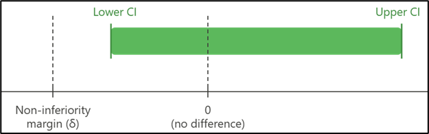

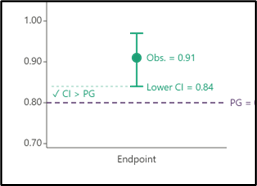

## How are Performance Goals Calculated?

Performance Goals define the **worst acceptable outcome** a new device must beat to be approved.

**Process:**

1. Identify comparable approved devices
2. Get their safety & efficacy preformances from their clinical studies
3. Propose these PGs to regulatory authorities (FDA) for approval
4. Authorities can accept, reject, or modify based on clinical rationale

**Safety:** Maximum acceptable harm

**Efficacy:** Minimum acceptable clinical benefit preserved

## Case Study:

The BioMimics 3D Stent Study:

A pivotal single-arm performance goal study for a peripheral vascular stent (to treat peripheral vascular disease).

Goal:

1. Propose performance goal endpoints for safety & efficacy to show to regulatory authorities.
2. Demonstrate that the new treatment stays below/ above the approved performance goals.

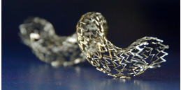

😊 If both preformance goals are met – the treatment successfully demonstrates non-inferiority 😊

## Proposed Performance Goal Endpoints:

Step 1. Conduct a targeted literature review of clinical trials of comparable stents.

Step 2. Conduct an aggregate-level meta-analysis using a 2007 FDA guidance document

*‘Performance Goals and Endpoint Assessments for Clinical Trials of Femoropopliteal Bare Nitinol Stents in Patients with Symptomatic Peripheral Arterial Disease’*

Includes three studies of similar stents assessing the primary endpoints for safety & efficacy.

## Proposed Endpoints:

**Safety (30-day):** Maximum acceptable level of harm

- Amputation
- Death
- Target Vessel Revascularisation (TVR)
- **Primary composite (Combined amputation, death, TVR)**

**Efficacy (12-month):** Minimum clinical benefit that must be preserved

- **Rutherford Classification Change (improved/stable, worsened by x1, worsened by x2)**

## Meta Analysis:

A logit-transformation was applied (*extreme proportions*), variance was pooled using a generalised linear mixed model (*robust with sample sample sizes*), with study-level variances drawn from each study’s observed proportion (*not assuming homogeneity accross studies*).

- The upper/lower confidence interval bounds — not point estimate — were proposed to the regulators to account for the uncertainty.
- Note: With only 3 studies available, confidence intervals are wide (conservative)

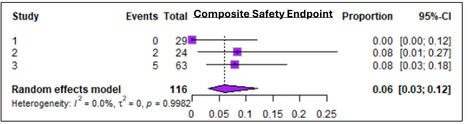

## Performance Goals & Decision Criteria

Table 1

| Endpoint | Pooled Rate (95% CI) | Performance Goal |
| --- | --- | --- |
| **Safety — 30 Days** |  |  |
| Composite (Death, Amputation, TVR) | 6.0% [2.9–12.1%] | ≤ 12% |
| **Efficacy — 12 Months** |  |  |
| RCC Score 1: Improved / No Change | 95.8% [87.9–98.6%] | ≥ 88% |

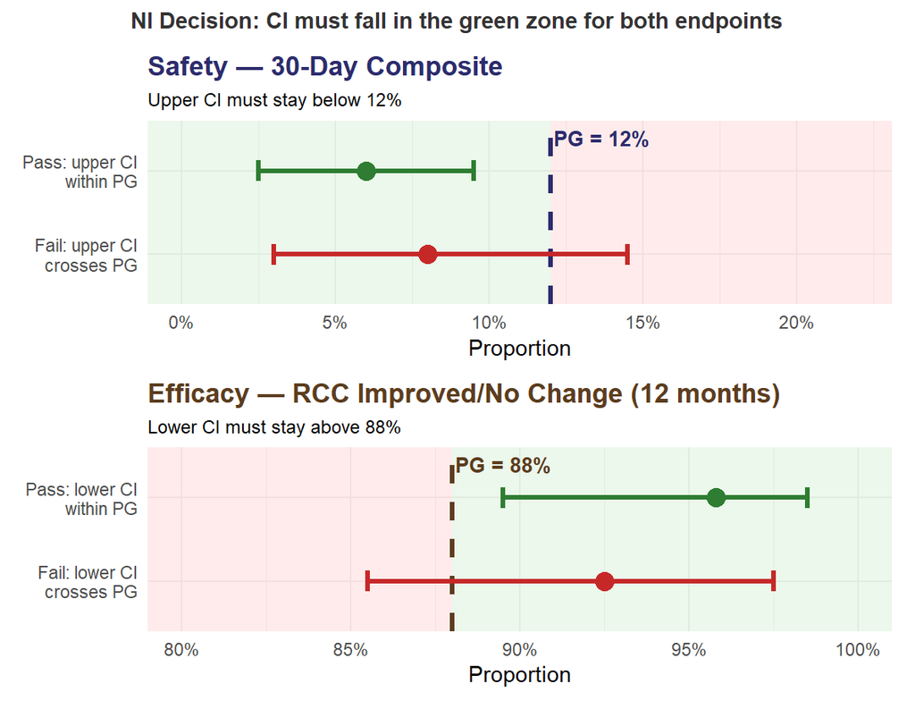

# Section Two

- Confidence Intervals for Proportions
- Simulation Study
- Sample Size Calculation
- Shiny App
- Final Steps

# Confidence Intervals for proportions

[figure not shown]

**Complications** = lower boundary

[figure not shown]

**High Success Rate** = upper boundary

## Wald’s Confidence Interval

$$\hat{p} \;\pm\; z_{1-\alpha/2}\sqrt{\frac{\hat{p}(1-\hat{p})}{n}}$$

[figure not shown]

- Assumes $\hat{p}$ is normally distriubuted
  - Impossible CI bounds, not within [0,1]
  - Underestimates uncertainty at bounderies
  - Poor coverage, below nominal 95% power

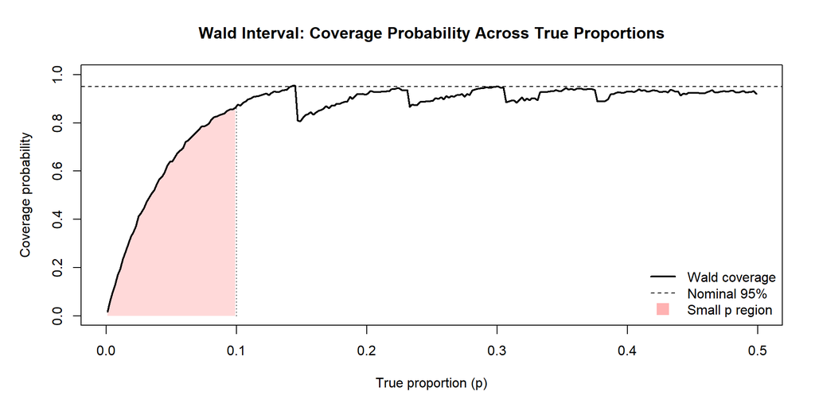

Wald interval coverage across a range of true proportions when n = 20. For small values of p (shaded region), coverage falls well below 95%.

## Alternatives

- Wilson Score Interval
- Wilson Score Interval *(with continuity correction)*
- Agresti–Coull Interval
- Clopper–Pearson Interval
- Jeffreys Interval

## Wilson Score Interval

$$\frac{
\hat{p} + \dfrac{z^2}{2n}
\;\pm\;
z \sqrt{
\dfrac{\hat{p}(1 - \hat{p})}{n} + \dfrac{z^2}{4n^2}
}
}{
1 + \dfrac{z^2}{n}
}$$

- Inverts score test for a binomial proportion
- Keep values of $p$ that would **not be rejected** by the observed data
- Wald deems estimate to be center of interval
- Wilson fixes that with:

$$\tilde{p}
=
\frac{
\hat{p} + \dfrac{z^2}{2n}
}{
1 + \dfrac{z^2}{n}
}$$

Adjusting center of interval

$$\dfrac{z^2}{2n}$$

Pulls centre away from 0 or 1

## Wilson Score Interval *(with continuity correction)*

$$\text{derived from a score test:}
\quad
\frac{(\hat{p} - p)^2}{\hat{p}(1-\hat{p})/n}$$

- **Prop.test comes in `stats` package which is loaded with base R**
  - Essentially Wilson Score Interval with *continuity correction enabled by default*
- *Real name: Wilson score interval with continuity correction*
- Also a test inversion
  - Keep values of $p$ that would **not be rejected** by the observed data
  - **Continuity correction**
    - Adjusts the cutoff by .5

## Agresti-Coull Interval

$$\hat{p} = \frac{x}{n}
\qquad \longrightarrow \qquad
\tilde{p} = \frac{x + 2}{n + 4}$$

Then calculates CI:

$$\tilde{p}
\;\pm\;
1.96
\sqrt{
\frac{
\tilde{p}(1-\tilde{p})
}{
n+4
}
}$$

*Essentially improved **Wald with pseudo-observations***

## Clopper-Pearson Interval

$$\left[
\mathrm{Beta}^{-1}\!\left(\tfrac{\alpha}{2};\; x,\; n - x + 1\right),
\;\;
\mathrm{Beta}^{-1}\!\left(1 - \tfrac{\alpha}{2};\; x + 1,\; n - x\right)
\right]$$

- Based on **exact** binomial distribution

  $$X \sim \text{Binomial}(n, p)$$
- Inverts the exact binomial test
  - Keep values of $p$ that would **not be rejected** by the observed data

## Jeffrey Interval

$$\left[
\mathrm{Beta}^{-1}\!\left(\tfrac{\alpha}{2};\; x + \tfrac{1}{2},\; n - x + \tfrac{1}{2}\right),
\;\;
\mathrm{Beta}^{-1}\!\left(1 - \tfrac{\alpha}{2};\; x + \tfrac{1}{2},\; n - x + \tfrac{1}{2}\right)
\right]$$

Also assumes binomial distribution

$$X \sim \text{Binomial}(n, p)$$

- Based on Bayesian idea
  - Works well for frequentist problems
- Start with weak prior beliefs on $p$

$$p \sim \mathrm{Beta}\left(\frac{1}{2}, \frac{1}{2}\right)$$

# Simulation Study

## Framework

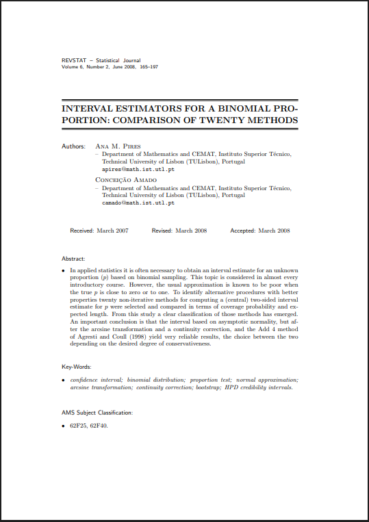

**Pires & Amado (2008):** *Interval estimators for a binomial proportion: Comparison of twenty methods*

- Behaviour evaluated under:
  - Coverage probability
  - Average expected 95% CI Width
  - Under different n

## Coverage Probability n = 50

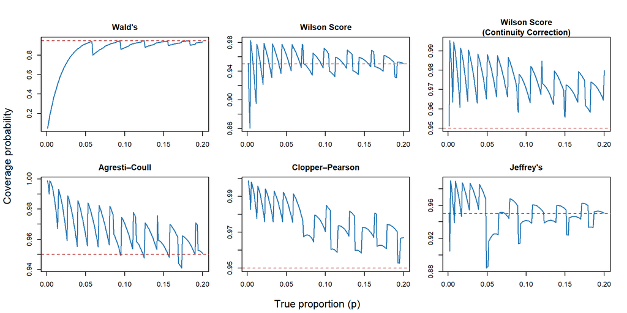

Dashed red = nominal 95%.

## Coverage Probability n = 100

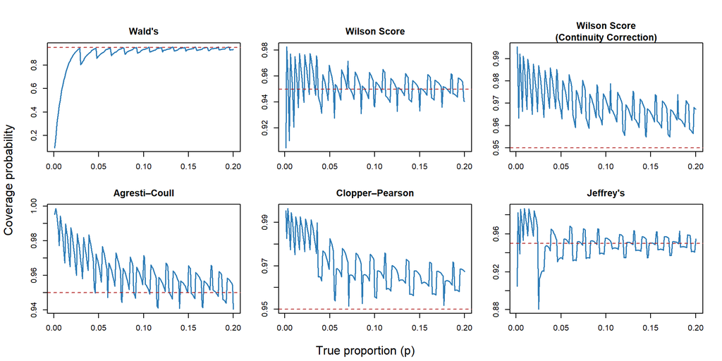

Dashed red = nominal 95%.

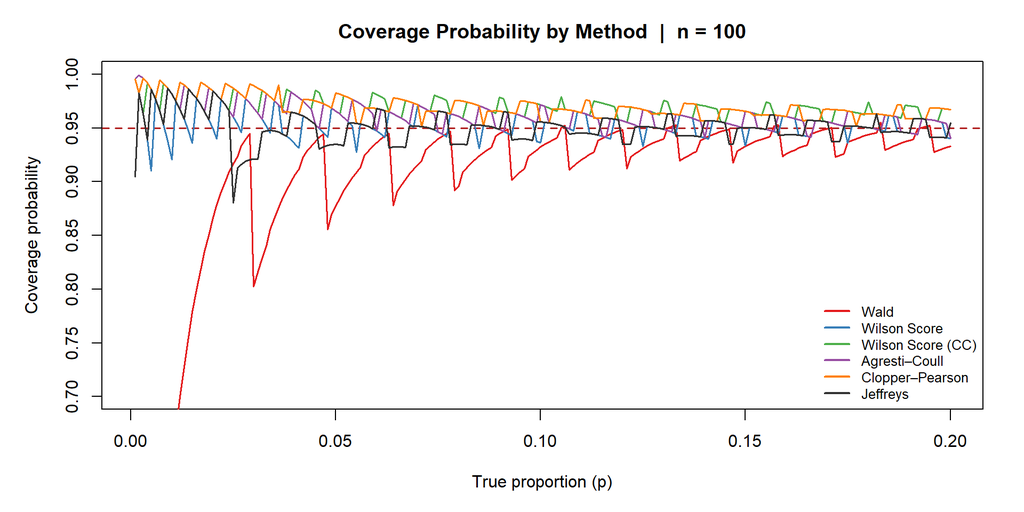

## Expected 95% CI Width n = 20

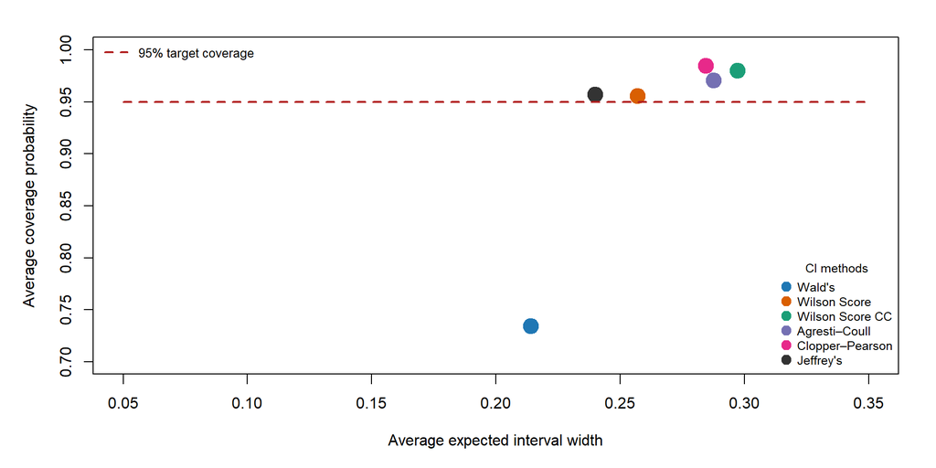

## Expected 95% CI Width n = 50

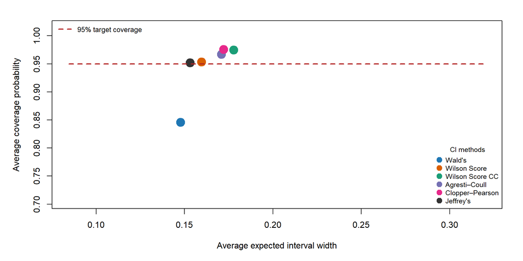

## Expected 95% CI Width n = 100

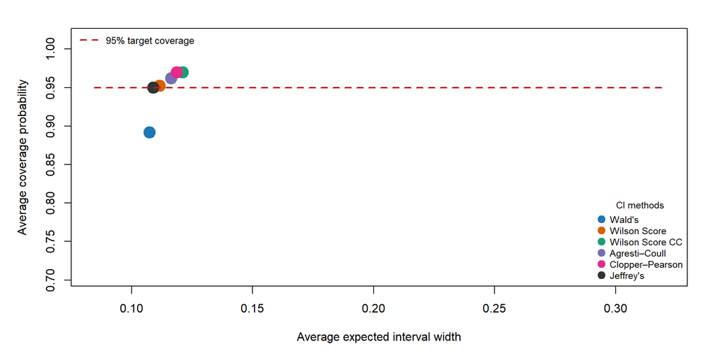

## Simulation Study: Key Takeaways

**Wald’s interval fails** at small proportions - undercoverage regardless of $n$

**Clopper–Pearson & Wilson CC** over-cover - unnecessarily wide intervals

**Wilson Score & Jeffreys** best balance coverage accuracy and interval width

**Recommended:** Wilson Score or Jeffreys for small proportion clinical endpoints

[figure not shown]

# Sample Size Calculation

## Safety Endpoint

- Proposed Safety Endpoint for Composite (Death, Amputation, TVR): **≤ 12%**
- Approved Safety Endpoint for Composite (Death, Amputation, TVR): **≤ 11%**
- Chosen Proportion Method: Exact Test

|  | Value |
| --- | --- |
| Significance ($\alpha$) | 0.025 (one-sided) |
| Power | 90% |
| Approved Safety Endpoint (PG) | 0.11 |
| Assumed Safety Endpoint ($p_1$) | 0.05 |

## Software Comparison

[figure not shown]

**NCSS PASS** n = 220

[figure not shown]

**nQuery** n = 232

**R EnvStats** n = 220 | **R binom** n = 256

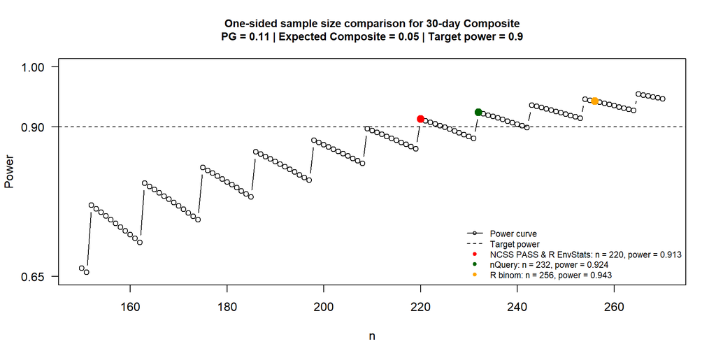

## Why the saw-tooth shape?

It is a discrete fraction: $\dfrac{\text{critical value}}{n}$

e.g. $\dfrac{1}{50},\quad\dfrac{1}{51},\quad\dfrac{1}{52},\quad\dfrac{2}{53}$

- Sample size increases but the **critical value** remains constant → power declines
- Then the **critical value** jumps → fraction rises → easier again → power peaks.

**Different Software:**

- n=220: First N hitting 90% (but immediately drops)
- n=232: Power reliably above 90%
- n=256: Power never drops below 90% for any N

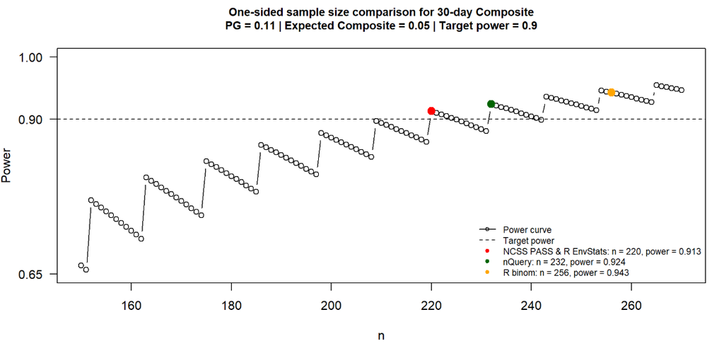

# Thank You

- **Gatekeeping approach:** safety must be demonstrated before efficacy is analysed.
- Explore **joint Bayesian modelling** of safety & efficacy simultaneously.
- Incorporate historical data using a **Bayesian weighting framework**.

## References

- Cuzick & Sasieni (2022). doi: 10.1038/s41416-022-01937-w
- Sandie et al. (2022). doi: 10.1186/s13063-022-06118-x
- FDA (2016). Non-Inferiority Clinical Trials to Establish Effectiveness. https://www.fda.gov/media/78504/download
- Werk et al. (2008). doi: 10.1161/CIRCULATIONAHA.107.735985
- Tepe et al. (2008). doi: 10.1056/NEJMoa0706356
- Pires & Amado (2008). Interval estimators for a binomial proportion: Comparison of twenty methods. *REVSTAT*